# Examen 1 - Ejercicio 2

*175904 - Jorge III Altamirano Astorga*

*177508 - Uriel Miranda Miñón*

## Carga de Datos

```r
set.seed(28882)
Rcpp::sourceCpp('../../../../src/factorizacion_mat/descenso_estocastico.cpp')
Rcpp::sourceCpp('../../../../src/factorizacion_mat/calc_error_bias.cpp')
recm <- function(calif, pred){
  sqrt(mean((calif - pred)^2))
}
muestra_nf <- read_csv('movielens/ratings.csv', progress = F,
                          col_names = TRUE, na = c("", "NA", "NULL"));
pelis_nombres <- read_csv('movielens/movies.csv',  progress = F,
                          col_names = TRUE, na = c("", "NA", "NULL"));
names(pelis_nombres) <- c('peli_id','nombre')
names(muestra_nf) <- c('usuario_id_orig','peli_id','calif','timestamp')
head(pelis_nombres)
```

| peli_id | nombre | None |
| --- | --- | --- |
| 1 | Toy Story (1995) | Adventure\|Animation\|Children\|Comedy\|Fantasy |
| 2 | Jumanji (1995) | Adventure\|Children\|Fantasy |
| 3 | Grumpier Old Men (1995) | Comedy\|Romance |
| 4 | Waiting to Exhale (1995) | Comedy\|Drama\|Romance |
| 5 | Father of the Bride Part II (1995) | Comedy |
| 6 | Heat (1995) | Action\|Crime\|Thriller |

```r
muestra_nf <- muestra_nf %>%
  mutate(usuario_id = as.integer(as.factor(usuario_id_orig)))
dim(muestra_nf)
```

```
## [1] 20000263        5
```

```r
head(muestra_nf)
```

| usuario_id_orig | peli_id | calif | timestamp | usuario_id |
| --- | --- | --- | --- | --- |
| 1 | 2 | 3.5 | 1112486027 | 1 |
| 1 | 29 | 3.5 | 1112484676 | 1 |
| 1 | 32 | 3.5 | 1112484819 | 1 |
| 1 | 47 | 3.5 | 1112484727 | 1 |
| 1 | 50 | 3.5 | 1112484580 | 1 |
| 1 | 112 | 3.5 | 1094785740 | 1 |

## Entrenamiento y Validación

Construye una muestra de entrenamiento y una de validación:

```r
set.seed(28882)
frac <- trunc((max(muestra_nf$usuario_id)*1.0),0)
muestra_nf <- muestra_nf[1:sum(muestra_nf$usuario_id<=frac),]
valida_usuarios <- sample(unique(muestra_nf$usuario_id),  max(unique(muestra_nf$usuario_id))*.25)
valida_pelis <- sample(unique(muestra_nf$peli_id), 2000)
dat_2 <- muestra_nf %>%
  mutate(valida_usu = usuario_id %in% valida_usuarios) %>%
  mutate(valida_peli = peli_id %in% valida_pelis)

dif_movies <- unique(dat_2$peli_id)
# En validación van aquellas evaluaciones de las películas y
# usuario que seleccionamos
dat_valida <- filter(dat_2, valida_usu & valida_peli)
# En entrenamiento va el resto: algunas evaluaciones de usuarios
# seleccionados van en entrenamiento, por ejemplo (para películas
# no seleccionadas en validación)
dat_entrena <- filter(dat_2, !valida_usu | !valida_peli)

nrow(dat_entrena) + nrow(dat_valida)
```

```
## [1] 20000263
```

```r
# rm(list = c('muestra_nf','muestra_nf'))
```

```r
# configuración para spark
config <- spark_config()
config$`sparklyr.shell.driver-memory` <- "48G"
config$sparklyr.cores.local <- 4
config$spark.memory.fraction <- 0.9
sc <- spark_connect(master="local",
              # version = "2.1.0",
              config = config,
              spark_home = "/home/rstudio/.cache/spark/spark-2.2.0-bin-hadoop2.7")
spark_set_checkpoint_dir(sc, './checkpoint')
```

```r
sc <- spark_connect(master = "local", config = config)
```

```
## Re-using existing Spark connection to local
```

```r
spark_set_checkpoint_dir(sc, './checkpoint')
```

```r
media_gral_ent <- mean(dat_entrena$calif)
dat <- dat_entrena %>%
      as_data_frame %>%
      select(peli_id, usuario_id, calif)
dat_tbl <- copy_to(sc, dat, overwrite = TRUE)
```

## Descenso Estocástico

Utiliza descenso estocástico o mínimos cuadrados alternados para encontrar factores latentes.

Se utiliza el método de mínimos cuadrados con 8 factores latentes.

```r
modelo <- ml_als(dat_tbl,
              rating_col = 'calif',
              user_col = 'usuario_id',
              item_col = 'peli_id',
              rank = 8, reg_param = 0.05,
              checkpoint_interval = 5,
              max_iter = 30)
```

```r
valida_tbl <- copy_to(sc, dat_valida)
preds <- sdf_predict(valida_tbl, modelo) %>% collect() #traemos a R con collect
```

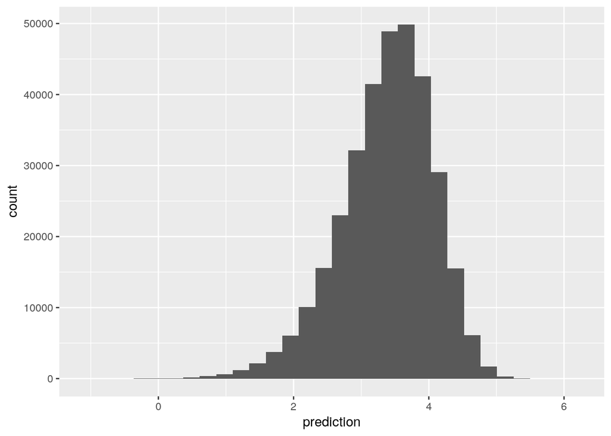

```r
ggplot(preds, aes(x = prediction)) + geom_histogram()
```

## Factores Latentes

Evalúa el modelo de factores latentes que ajustaste usando la muestra de validación y ajusta parámetros si es necesario para mejorar el desempeño.

```r
preds$prediction[is.nan(preds$prediction)] <- media_gral_ent
preds %>% ungroup %>% summarise(error = recm(calif, prediction))
```

| error |
| --- |
| 0.7999106 |

```r
V_df <- collect(modelo$item_factors)
dim(V_df)
```

```
## [1] 26667    10
```

```r
head(dat_2)
```

| usuario_id_orig | peli_id | calif | timestamp | usuario_id | valida_usu | valida_peli |
| --- | --- | --- | --- | --- | --- | --- |
| 1 | 2 | 3.5 | 1112486027 | 1 | TRUE | FALSE |
| 1 | 29 | 3.5 | 1112484676 | 1 | TRUE | FALSE |
| 1 | 32 | 3.5 | 1112484819 | 1 | TRUE | FALSE |
| 1 | 47 | 3.5 | 1112484727 | 1 | TRUE | FALSE |
| 1 | 50 | 3.5 | 1112484580 | 1 | TRUE | FALSE |
| 1 | 112 | 3.5 | 1094785740 | 1 | TRUE | FALSE |

Explica cómo hacer predicciones a partir del modelo (predicción de la calificación 1-5). ¿Qué películas recomendarías para el usuario usuario 4000 y el usuario 6000, y usuario 1333? (que no haya visto).

El sistema puede proponer calificaciones para un usuario con base en las calificaciones que posee; por esa razón debemos ingresar al modelo las películas que no ha calificado el usuario para saber el pronóstico de calificaciones. Con esa información podremos ordenar y por tanto recomendar aquellas que tengan el pronóstico mas alto.

```r
pred_usuario <- function(user){
  usr_predic <- dif_movies[!((filter(dat_2,usuario_id ==user)$peli_id) == dif_movies)]
  us <- data_frame(usuario_id = rep(user,length(usr_predic)), peli_id =usr_predic)
  us_sc <- copy_to(sc, us, overwrite=TRUE)
  us_pr <-sdf_predict(us_sc, modelo) %>% collect()
  us_recom<- us_pr[order(us_pr$prediction,decreasing = TRUE),] %>% head %>% left_join(pelis_nombres) %>% select (usuario_id,nombre)
  us_recom
}
```

```r
pred_usuario(4000)
```

| usuario_id | nombre |
| --- | --- |
| 4000 | I Belong (Som du ser meg) (2012) |
| 4000 | Patton Oswalt: Werewolves and Lollipops (2007) |
| 4000 | The War at Home (1979) |
| 4000 | Bill Hicks: Sane Man (1989) |
| 4000 | Big Night, The (1951) |
| 4000 | My Brother Tom (2001) |

```r
pred_usuario(6000)
```

| usuario_id | nombre |
| --- | --- |
| 6000 | Gurren Lagann: The Lights in the Sky are Stars (Gekijô ban Tengen toppa guren ragan: Ragan hen) (2009) |
| 6000 | Willie & Phil (1980) |
| 6000 | Hellhounds on My Trail (1999) |
| 6000 | Honest Liar, An (2014) |
| 6000 | On the Silver Globe (Na srebrnym globie) (1988) |
| 6000 | Welcome Mr. Marshall (Bienvenido Mister Marshall) (1953) |

```r
pred_usuario(1333)
```

| usuario_id | nombre |
| --- | --- |
| 1333 | Bo Burnham: what. (2013) |
| 1333 | Weeds (1987) |
| 1333 | Welcome Mr. Marshall (Bienvenido Mister Marshall) (1953) |
| 1333 | Honest Liar, An (2014) |
| 1333 | History of the Eagles (2013) |
| 1333 | Hellhounds on My Trail (1999) |

```r
sparklyr::spark_disconnect_all()
```

```
## [1] 1
```

## Examen

1. Construye una muestra de entrenamiento y una de validación

*Se muestra en la sección “Entrenamiento y Validación”.*

2. Utiliza descenso estocástico o mínimos cuadrados alternados para encontrar factores latentes.

*Se muestra en la sección “Descenso Estocástico”.*

3. Evalúa el modelo de factores latentes que ajustaste usando la muestra de validación y ajusta parámetros si es necesario para mejorar el desempeño.

*Se muestra en la sección “Factores Latentes”.*

4. Explica cómo hacer predicciones a partir del modelo (predicción de la calificación 1-5). ¿Qué películas recomendarías para el usuario usuario 4000 y el usuario 6000, y usuario 1333? (que no haya visto).

*El sistema puede proponer calificaciones para un usuario con base en las calificaciones que posee; por esa razón debemos ingresar al modelo las películas que no ha calificado el usuario para saber el pronóstico de calificaciones. Con esa información podremos ordenar y por tanto recomendar aquellas que tengan el pronóstico mas alto.*

Nota: si tienes problemas de memoria, por ejemplo, piensa en estrategias para resolverlo. Puedes correrlo en una máquina más grande, o intentar muestrar una fracción relativamente grande de usuarios.